# USA Air Quality Analysis

25 November 2016

## Background

This Analysis is to access change in air quality using PM2.5 particulate matter from the first time it was tracked in 1999 to the 2015(2016 full data is still not available). Data was obtained from Environment Protection Agency.

Daily pm2.5 (88101) http://aqsdr1.epa.gov/aqsweb/aqstmp/airdata/download_files.html#Daily

Data Dictionary http://aqsdr1.epa.gov/aqsweb/aqstmp/airdata/FileFormats.html#_format_4

```r
airquality_1999 <- read.table("../daily_88101_1999.csv",sep=",",header = TRUE,stringsAsFactors = FALSE)
airquality_2015 <- read.table("../daily_88101_2015.csv",sep=",",header = TRUE,stringsAsFactors = FALSE)
```

Rename Arthmetic.Mean to Pm2.5 variable

```r
library("reshape")
airquality_1999 <-rename(airquality_1999,c(Arithmetic.Mean="pm2.5"))
airquality_2015 <-rename(airquality_2015,c(Arithmetic.Mean="pm2.5"))
```

Check statistics of the pm2.5 variable (micrograms/meter cube)

```r
summary(airquality_1999$pm2.5)
```

```
##    Min. 1st Qu.  Median    Mean 3rd Qu.    Max.
##    0.00    7.20   11.60   13.82   18.00  157.10
```

```r
summary(airquality_2015$pm2.5)
```

```
##    Min. 1st Qu.  Median    Mean 3rd Qu.    Max.
##  -7.545   4.600   7.148   8.484  10.800 270.200
```

Checking the dimensions

```r
dim(airquality_1999)
```

```
## [1] 103807     29
```

```r
dim(airquality_2015)
```

```
## [1] 390090     29
```

The number of recordings are more since there might have been an increase in number of testing facilities to check air quality since 1999.

Lets compare the two years

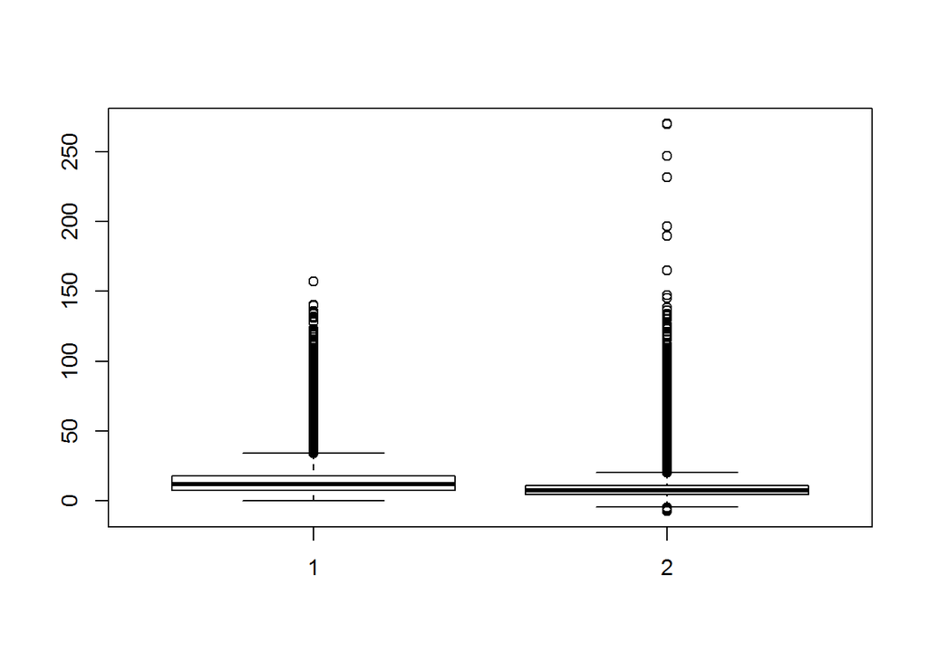

```r
boxplot(airquality_1999$pm2.5,airquality_2015$pm2.5)
```

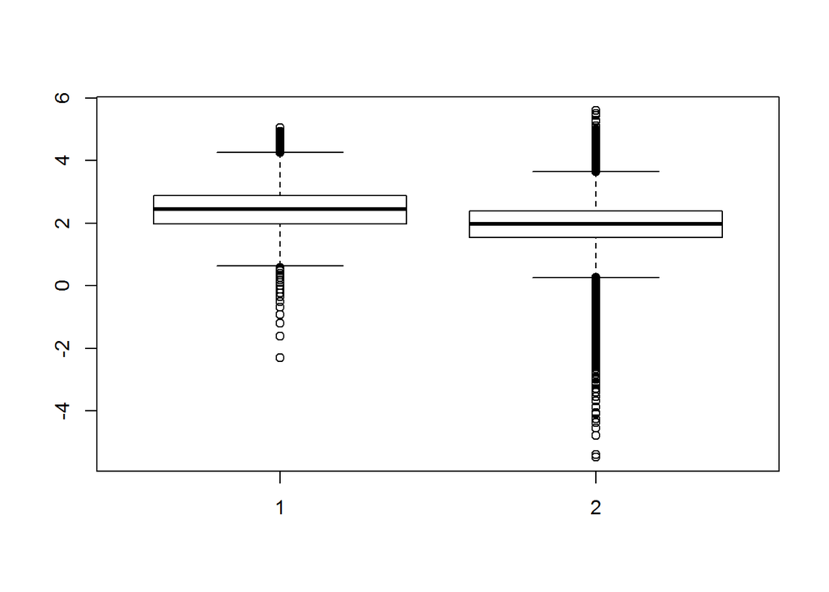

```r
boxplot(log(airquality_1999$pm2.5),log(airquality_2015$pm2.5))
```

Now, lets check the negative values for 2015

```r
negative_2015 <- airquality_2015$pm2.5<0
str(negative_2015)
```

```
##  logi [1:390090] FALSE FALSE FALSE FALSE FALSE FALSE ...
```

```r
sum(negative_2015,na.rm=TRUE)
```

```
## [1] 3650
```

```r
mean(negative_2015)
```

```
## [1] 0.009356815
```

So, there 3650 records less than 0 which is .9%, not that big. Check for negative values in 2015

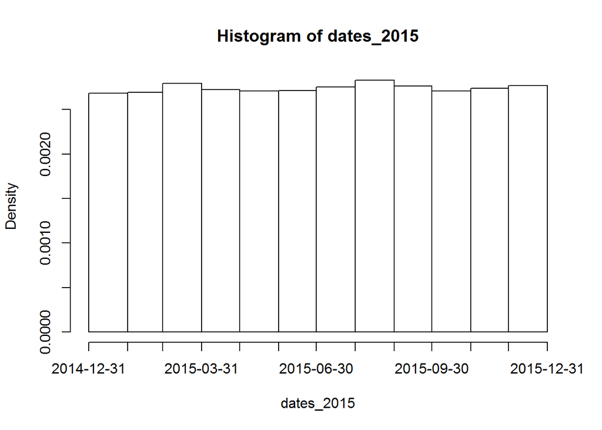

```r
dates_2015 <-airquality_2015$Date.Local
dates_2015<- as.Date(as.character(dates_2015),format="%Y-%m-%d")
hist(dates_2015,"month")
```

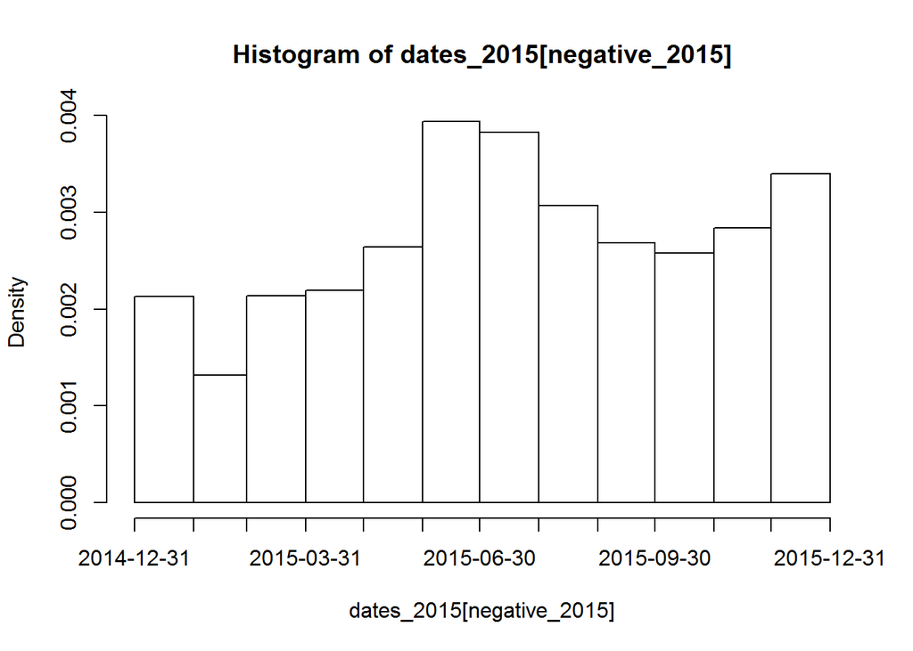

```r
hist(dates_2015[negative_2015],"month")
```

Seems there are more negative values during june and july. May be measurement error, need to get domain expert help to see why negative values are tracked. For now, since the values are less thab 1% . We can move forward.

```r
attach(airquality_1999)
sites_nyc_1999<-unique(subset(airquality_1999,State.Code=="36",select = c(County.Code,Site.Num)))
detach(airquality_1999)
attach(airquality_2015)
sites_nyc_2015<-unique(subset(airquality_2015,State.Code=="36",select = c(County.Code,Site.Num)))
detach(airquality_2015)

sites_nyc_1999<-paste(sites_nyc_1999[,1],sites_nyc_1999[,2],sep=".")
sites_nyc_2015<-paste(sites_nyc_2015[,1],sites_nyc_2015[,2],sep=".")
```

Check which monitors are same between 1999 and 2015 Taking intersection

```r
both_mon<-intersect(sites_nyc_1999,sites_nyc_2015)
```

```r
airquality_1999$County.Site<- with(airquality_1999,paste(airquality_1999$County.Code,airquality_1999$Site.Num,sep = "."))

airquality_2015$County.Site<- with(airquality_2015,paste(airquality_2015$County.Code,airquality_2015$Site.Num,sep = "."))

nyc_mon_cnt99 <-subset(airquality_1999,airquality_1999$State.Code=="36" & airquality_1999$County.Site %in% both_mon)

nyc_mon_cnt15 <-subset(airquality_2015,airquality_2015$State.Code=="36" & airquality_2015$County.Site %in% both_mon)
```

Now lets check the number of observations captured on the same monitors between 2015 and 1999 in NYC

```r
dim(nyc_mon_cnt15)
```

```
## [1] 3231   30
```

```r
dim(nyc_mon_cnt99)
```

```
## [1] 568  30
```

We can that in 2015 there are around 6 times observations captured.

```r
 sapply(split(nyc_mon_cnt15,nyc_mon_cnt15$County.Site),nrow)
```

```
##    1.12     1.5   101.3    29.2    29.5    31.3   5.110 67.1015   85.55
##     116     233     798     111     115      57     846     838     117
```

```r
 sapply(split(nyc_mon_cnt99,nyc_mon_cnt99$County.Site),nrow)
```

```
##    1.12     1.5   101.3    29.2    29.5    31.3   5.110 67.1015   85.55
##      28      54     108      49      48     104      88      84       5
```

Lets concentrate on a particular monitor for now

```r
mon99 <- subset(airquality_1999,airquality_1999$State.Code==36 & airquality_1999$County.Code==101 & airquality_1999$Site.Num==3)

mon15 <- subset(airquality_2015,airquality_2015$State.Code==36 & airquality_2015$County.Code==101 & airquality_2015$Site.Num==3)

dim(mon99)
```

```
## [1] 108  30
```

```r
dim(mon15)
```

```
## [1] 798  30
```

Plot the values for each year

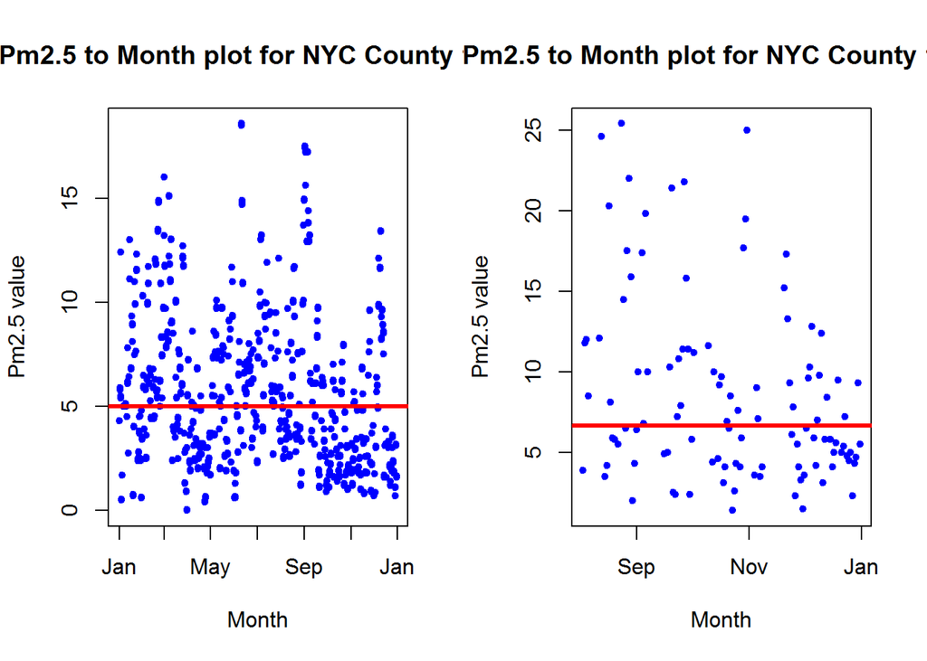

```r
par(mfrow=c(1,2))
plot(as.Date(as.character(mon15$Date.Local),format="%Y-%m-%d"),mon15$pm2.5,xlab = "Month",ylab = "Pm2.5 value",pch=20,col=4)
abline(h=median(mon15$pm2.5),col="red",lwd=3)
title("2015 Pm2.5 to Month plot for NYC County 101 Site 3")

plot(as.Date(as.character(mon99$Date.Local),format="%Y-%m-%d"),mon99$pm2.5,xlab = "Month",ylab = "Pm2.5 value",pch=20,col=4)
abline(h=median(mon99$pm2.5),col="red",lwd=3)
title("1999 Pm2.5 to Month plot for NYC County 101 Site 3")
```

Set the same range for both plots and then plot the points

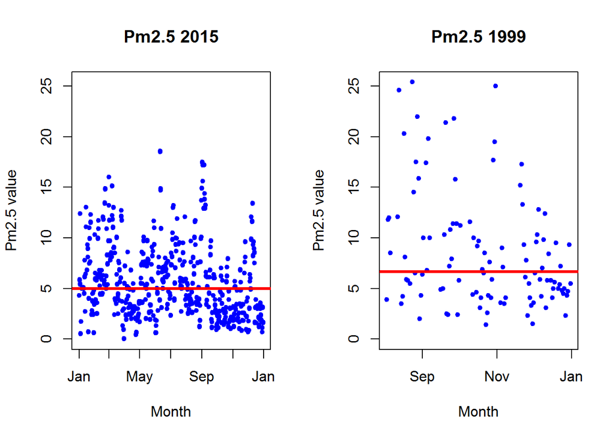

```r
plot_range<- range(mon15$pm2.5,mon99$pm2.5)

par(mfrow=c(1,2))
plot(as.Date(as.character(mon15$Date.Local),format="%Y-%m-%d"),mon15$pm2.5,xlab = "Month",ylab = "Pm2.5 value",pch=20,col=4,ylim = plot_range)
abline(h=median(mon15$pm2.5),col="red",lwd=3)
title("Pm2.5 2015")

plot(as.Date(as.character(mon99$Date.Local),format="%Y-%m-%d"),mon99$pm2.5,xlab = "Month",ylab = "Pm2.5 value",pch=20,col=4,ylim = plot_range)
abline(h=median(mon99$pm2.5),col="red",lwd=3)
title("Pm2.5 1999")
```

This shows average value has come down and also the spikes/high values has also come down

```r
mean99<- with(airquality_1999,tapply(airquality_1999$pm2.5, airquality_1999$State.Code, mean))

str(mean99)
```

```
##  num [1:52(1d)] 19.95 6.87 10.81 15.68 17.74 ...
##  - attr(*, "dimnames")=List of 1
##   ..$ : chr [1:52] "1" "2" "4" "5" ...
```

```r
summary(mean99)
```

```
##    Min. 1st Qu.  Median    Mean 3rd Qu.    Max.
##   5.100   9.529  12.350  12.500  15.700  19.950
```

```r
frame99<-data.frame(state=names(mean99),mean=mean99)
```

[output not shown]

[output not shown]